# Reproducible Research: Peer Assessment 1

Vish Murden

2015/08/17

# Introduction

In this report we investigate the use of data as collected via an actvity monitoring device that captures personal movement.

The measurements are taken from a device that collects the number of steps taken over a 5 minute intervals through out the day. The data recording is taken over a 2 month period for a given anonymouse individual during the months of October - Novemeber 2012.

## Loading and preprocessing the data

The [data](https://d396qusza40orc.cloudfront.net/repdata%2Fdata%2Factivity.zip) was originally sourced from the Coursera run Reproducible Reseach course, and a unzip copy retained in the data folder.

```r
library(dplyr)
library(lattice)

data <- read.csv("./data/activity.csv", colClasses=c("numeric", "character", "numeric"))
data$date <- as.Date(data$date, "%Y-%m-%d")
options(digits=2,scipen=999) # display doubles to 2dp, + disable scientific notation
```

Using this data, we’ll ask a number of question and derive relavent meaning.

## What is mean total number of steps taken per day?

Below we can see a summary of the total number of steps taken per day where a recording was available.

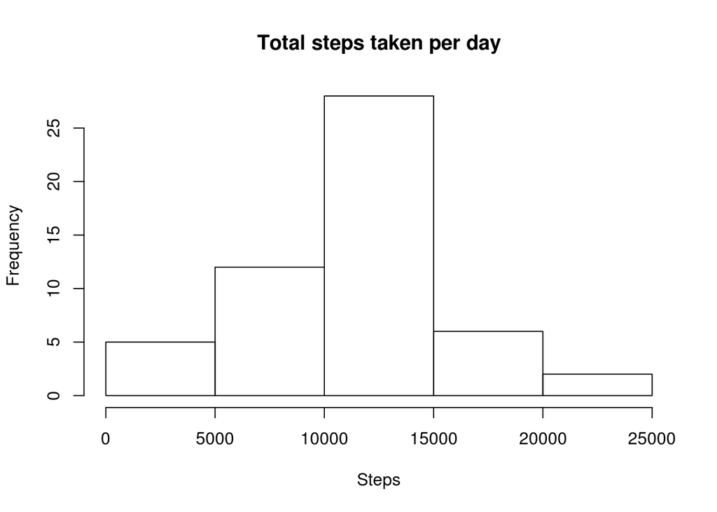

```r
data_summary <- summarise(groupbydate, totalsteps=sum(steps))
hist(data_summary$totalsteps, main = "Total steps taken per day", xlab = "Steps")
```

It can be sean that the mean value of steps take is 10766.19 whilst the median is 10765

## What is the average daily activity pattern?

In the below plot we observe the average steps taken within the 5minute data within the day.

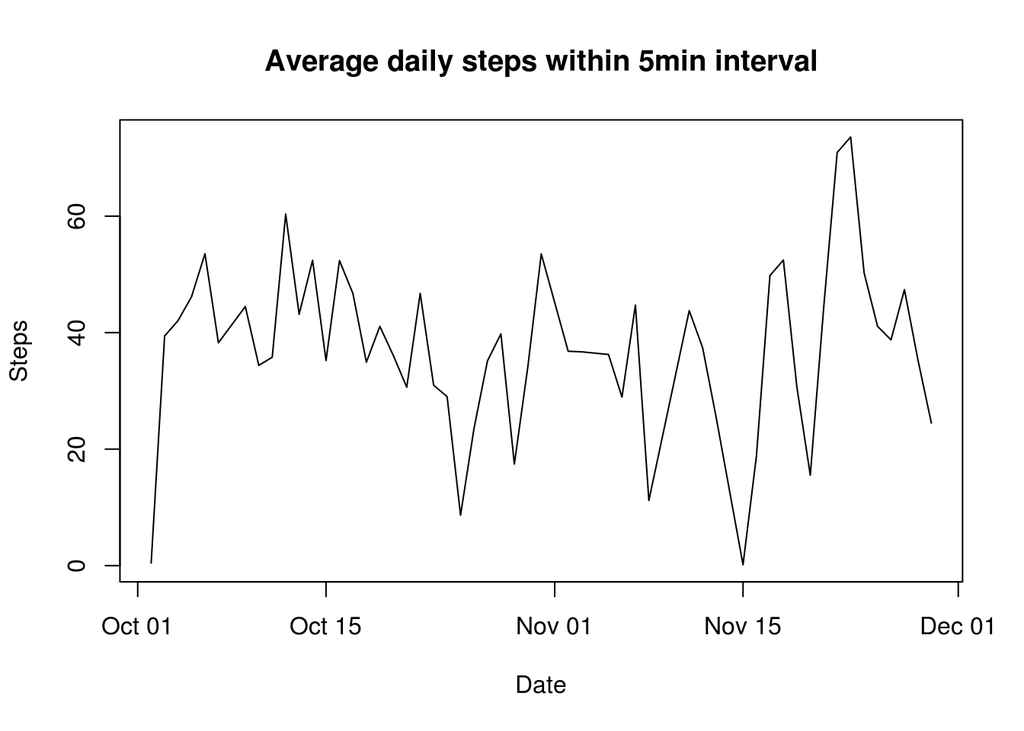

```r
data_summary <- summarise(groupbydate, avgsteps=mean(steps))
plot(data_summary, type="l", main = "Average daily steps within 5min interval", ylab = "Steps", xlab = "Date")
```

A maximmum number of average steps of 73.59 occured on 2012-11-23

## Imputing missing values

The original dataset comprises of 2304 samples in which a value was not provided, ie. NA. Such loss of data will skew our results a little.

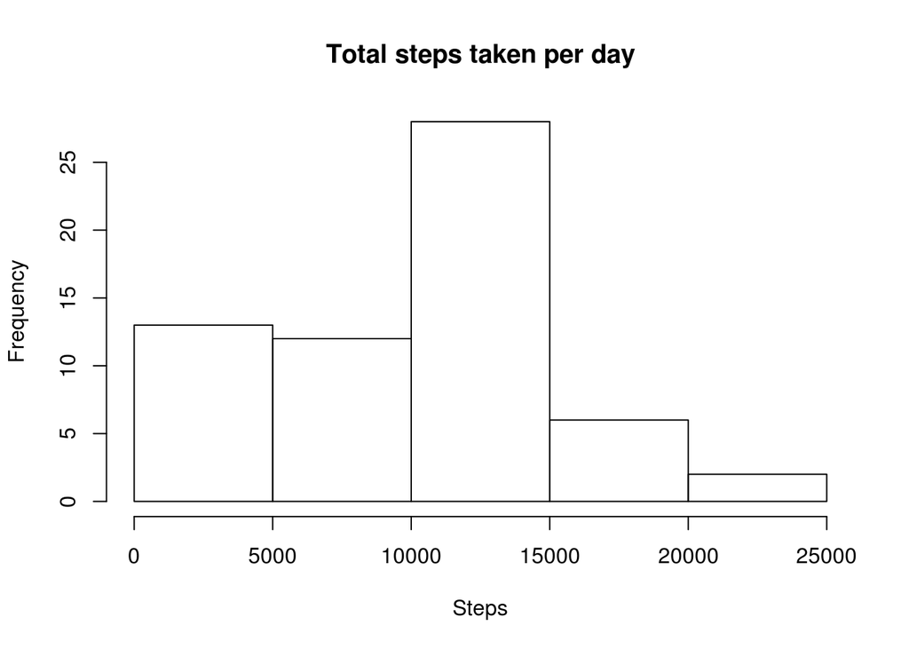

```r
reformmeddata <- merge(filtered_data, replaceNa(data,data_summary ), all=TRUE)
reformmeddata_summary <- summarise(group_by(reformmeddata,date), totalsteps=sum(steps))

# display mean value having replaced all NAs where possible
hist(reformmeddata_summary$totalsteps, main = "Total steps taken per day", xlab = "Steps")
```

```r
reformmeddata_meansteps <-  mean(reformmeddata_summary$totalsteps)
reformmeddata_mediansteps <- median(reformmeddata_summary$totalsteps)
```

Having replaced where possible all NA values with corresponding mean values of the day, and 0 where we have a NA and no pre-existing mean observation for a date. We can observe overall mean number of steps now as 9354.23 and the median number of steps as 10395. It can be seen that then reformatted data seems to give slighly different values compared to earlier on, where the mean was 10766.19 and median was 10765. Notability the mean number of steps is lower.

## Are there differences in activity patterns between weekdays and weekends?

Below is a plot of average daily steps per day, broken out by average steps taken in the weekend and weekday.

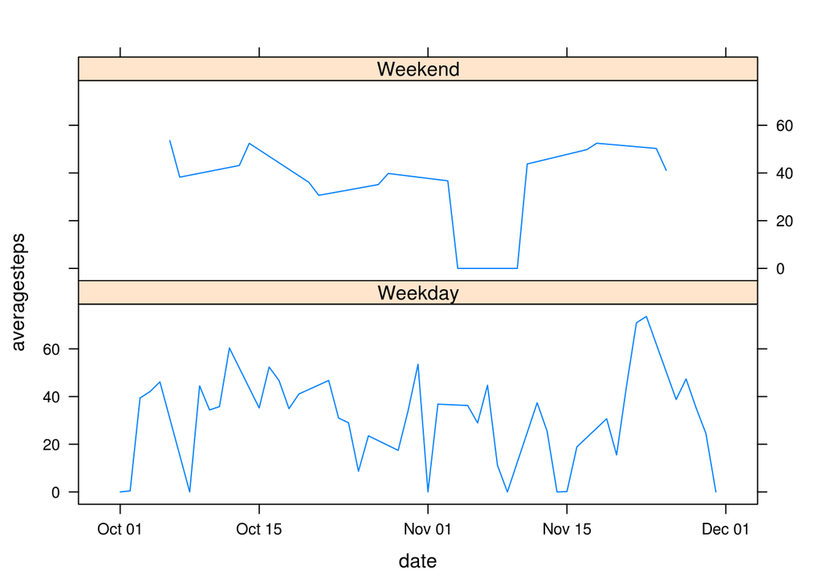

```r
xyplot(averagesteps ~ date | period, data = weekday_reformmeddata_summary, layout = c(1,2), type = "l")
```

Looking at the plot, we cannot see any discernable difference between foot activities between the varied periods.